```python
import numpy as np
```

# `Chapter#4 NumPy Basics: Arrays and Vectorized Computation`

# `Creating ndarrays` Pg#88 (106)

```python
# Nested sequences, like a list of equal-length lists, will be converted into a multidimensional array:

data2 = [[1, 2, 3, 4], [5, 6, 7, 8]]
data2
```

```
[[1, 2, 3, 4], [5, 6, 7, 8]]
```

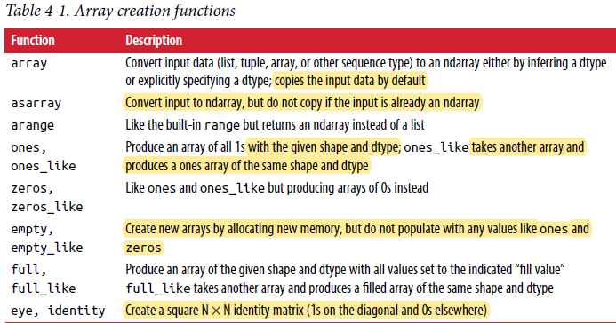

```python
# asarray()
# input is not an array
list1 = [12,13,14]
asArray = np.asarray(list1)
asArray
```

```
array([12, 13, 14])
```

```python
# asarray()
# input is already an array
arr1 = [12,13,14]
asArray1 = np.asarray(arr1)
asArray
```

```
array([12, 13, 14])
```

```python
# np.ones() >>> as an arg u can specify shape
onesArr = np.ones((2,3))
onesArr
```

```
array([[1., 1., 1.],
       [1., 1., 1.]])
```

```python
# np.ones_like() >>> as an arg u specify an array, it will infer the shape from that array and create ones array

testArr = np.array([12,14,16,18,20])

onesLikeArr = np.ones_like(testArr)
onesLikeArr
```

```
array([1, 1, 1, 1, 1])
```

```python
testArr1 = np.array([[1,2,3], [4,5,6]])

emptyLikeArr = np.empty_like(testArr1)
print(emptyLikeArr)
```

```
[[1 2 3]
 [4 5 6]]
```

```python
# np.full()  >>> 1st arg="shape", 2nd arg="fill_value"
# fill_value is what we want all elements to be...
# Here we want that all our elements should be 10

fullArr = np.full((3,3),10)
fullArr
```

```
array([[10, 10, 10],
       [10, 10, 10],
       [10, 10, 10]])
```

```python
# np.full_like()  >>> 1st 1rg ="arrName",2nd arg="fill_value"
# 1st arg will infer or preserve shape of array and create an array accordance with that shape
# and 2nd arg will fill whatever value we would want

testArr = np.array([[1,2,3,4,5], [6,7,8,9,10]])

fullLikeArr = np.full_like(testArr, 9)
fullLikeArr
```

```
array([[9, 9, 9, 9, 9],
       [9, 9, 9, 9, 9]])
```

```python
# np.eye() >>> arg="N" bcoz it creates N x N identity matrix, ones on the diagonal and 0 elsewhere

eyeArr = np.eye(4)
eyeArr
```

```
array([[1., 0., 0., 0.],
       [0., 1., 0., 0.],
       [0., 0., 1., 0.],
       [0., 0., 0., 1.]])
```

```python
# np.identity() arg="N"

identityArr = np.identity(5)
identityArr
```

```
array([[1., 0., 0., 0., 0.],
       [0., 1., 0., 0., 0.],
       [0., 0., 1., 0., 0.],
       [0., 0., 0., 1., 0.],
       [0., 0., 0., 0., 1.]])
```

# `Data Types for ndarrays` Pg#90 (108)

- It’s important to be cautious when using the numpy.string_ type, as string data in NumPy is fixed size and may truncate input without warning. pandas has more intuitive out-of-the-box behavior on non-numeric data.
- **Calling `astype` always creates a `new array` `(a copy of the data)`, even if the new dtype is the same as the old dtype.**

# `Basic Indexing and Slicing` Pg#94 (112)

- array slices are views on the original array. This means that the data is not copied, and any modifications to the view will be reflected in the source array.

# `Boolean Indexing` Pg#99 (117)

```python
names = np.array(['Bob', 'Joe', 'Will', 'Bob', 'Will', 'Joe', 'Joe'])
data = np.array([[ 0.0929, 0.2817, 0.769 , 1.2464],
                 [ 1.0072, -1.2962, 0.275 , 0.2289],
                 [ 1.3529, 0.8864, -2.0016, -0.3718],
                 [ 1.669 , -0.4386, -0.5397, 0.477 ],
                 [ 3.2489, -1.0212, -0.5771, 0.1241],
                 [ 0.3026, 0.5238, 0.0009, 1.3438],
                 [-0.7135, -0.8312, -2.3702, -1.8608]])
```

```python
data[names == "Bob"]
```

```
array([[ 0.0929,  0.2817,  0.769 ,  1.2464],
       [ 1.669 , -0.4386, -0.5397,  0.477 ]])
```

#### To select everything but 'Bob', you can either use `!=` or negate the condition using `~`:

```python
a = data[~(names == 'Bob')]

b = data[names != "Bob"]

print(a)
print("====================================================")
print(b)
```

```
[[ 1.0072e+00 -1.2962e+00  2.7500e-01  2.2890e-01]
 [ 1.3529e+00  8.8640e-01 -2.0016e+00 -3.7180e-01]
 [ 3.2489e+00 -1.0212e+00 -5.7710e-01  1.2410e-01]
 [ 3.0260e-01  5.2380e-01  9.0000e-04  1.3438e+00]
 [-7.1350e-01 -8.3120e-01 -2.3702e+00 -1.8608e+00]]
====================================================
[[ 1.0072e+00 -1.2962e+00  2.7500e-01  2.2890e-01]
 [ 1.3529e+00  8.8640e-01 -2.0016e+00 -3.7180e-01]
 [ 3.2489e+00 -1.0212e+00 -5.7710e-01  1.2410e-01]
 [ 3.0260e-01  5.2380e-01  9.0000e-04  1.3438e+00]
 [-7.1350e-01 -8.3120e-01 -2.3702e+00 -1.8608e+00]]
```

#### The `~` operator can be useful when you want to `invert a general condition`:

```python
cond = names == 'Bob'
```

```python
data[cond]
```

```
array([[ 0.0929,  0.2817,  0.769 ,  1.2464],
       [ 1.669 , -0.4386, -0.5397,  0.477 ]])
```

```python
data[~cond]
```

```
array([[ 1.0072e+00, -1.2962e+00,  2.7500e-01,  2.2890e-01],
       [ 1.3529e+00,  8.8640e-01, -2.0016e+00, -3.7180e-01],
       [ 3.2489e+00, -1.0212e+00, -5.7710e-01,  1.2410e-01],
       [ 3.0260e-01,  5.2380e-01,  9.0000e-04,  1.3438e+00],
       [-7.1350e-01, -8.3120e-01, -2.3702e+00, -1.8608e+00]])
```

Selecting data from an array by boolean indexing always creates a copy of the data, even if the returned array is unchanged.